# R Prediction Starter

John Young

March 13, 2017

## Let’s open the files and EDA

Read with `readr` package which is fast.

Let’s take a quick peak at the data from train and test.

| Id | region | date | O3 | PM10 | PM25 | NO2 | T2M |
| --- | --- | --- | --- | --- | --- | --- | --- |
| 1 | E12000001 | 2007-01-02 | 42.358 | 9.021 | NA | NA | 278.138 |
| 2 | E12000001 | 2007-01-03 | 49.506 | 5.256 | NA | NA | 281.745 |
| 3 | E12000001 | 2007-01-04 | 51.101 | 4.946 | NA | NA | 280.523 |
| 4 | E12000001 | 2007-01-05 | 47.478 | 6.823 | NA | NA | 280.421 |
| 5 | E12000001 | 2007-01-06 | 45.226 | 7.532 | NA | NA | 278.961 |
| 6 | E12000001 | 2007-01-07 | 53.226 | 5.607 | NA | NA | 281.504 |

| Id | region | date | O3 | PM10 | PM25 | NO2 | T2M |
| --- | --- | --- | --- | --- | --- | --- | --- |
| 18404 | E12000006 | 2012-05-28 | 75.980 | 20.876 | 19.123 | 9.713 | 290.787 |
| 18405 | E12000006 | 2012-05-29 | 73.084 | 21.660 | 17.794 | 8.417 | 288.474 |
| 18406 | E12000006 | 2012-05-30 | 59.350 | 21.925 | 17.699 | 10.878 | 289.889 |
| 18407 | E12000006 | 2012-05-31 | 45.991 | 14.549 | 11.386 | 10.302 | 287.815 |
| 18408 | E12000006 | 2012-06-01 | 52.210 | 11.208 | 9.545 | 8.598 | 287.627 |
| 18409 | E12000006 | 2012-06-02 | 68.120 | 10.118 | 7.838 | 6.656 | 286.108 |

There are a number of things we can do to prep and clean up the data for an initial prediction of mortality-rate.

- Region might be able to be broken down further.
- Date can be broken into month day year
- Missing values in train (may need to impute)
- log transformations of a few variables and the target
- new features mean and medians by region, month, day, year

[output not shown]

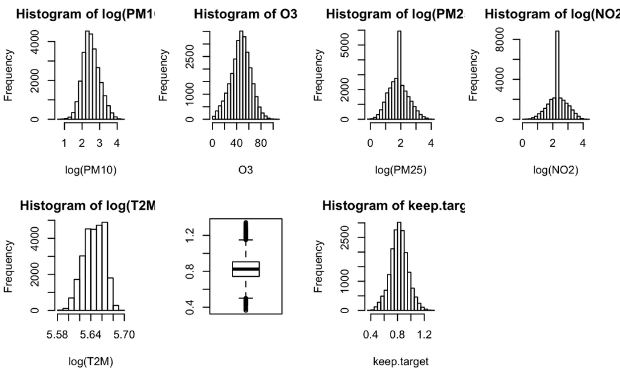

Let’s look at the new full feature set of data.

|  | Id | O3 | PM10 | PM25 | NO2 | T2M | RM_med | RM_mean |
| --- | --- | --- | --- | --- | --- | --- | --- | --- |
| 1 | 1 | 42.358 | 9.021 | 6.81 | 10.628 | 278.138 | 1.078120 | 1.082364 |
| 2 | 2 | 49.506 | 5.256 | 6.81 | 10.628 | 281.745 | 1.079233 | 1.080623 |
| 3 | 3 | 51.101 | 4.946 | 6.81 | 10.628 | 280.523 | 1.057961 | 1.070978 |
| 4 | 4 | 47.478 | 6.823 | 6.81 | 10.628 | 280.421 | 1.077268 | 1.082781 |
| 5 | 5 | 45.226 | 7.532 | 6.81 | 10.628 | 278.961 | 1.071410 | 1.074240 |
| 6 | 6 | 53.226 | 5.607 | 6.81 | 10.628 | 281.504 | 1.047075 | 1.089905 |

|  | Id | O3 | PM10 | PM25 | NO2 | T2M | RM_med | RM_mean |
| --- | --- | --- | --- | --- | --- | --- | --- | --- |
| 26284 | 26284 | 50.526 | 8.783 | 4.582 | 7.173 | 278.938 | 1.042747 | 0.9939712 |
| 26285 | 26285 | 57.951 | 6.422 | 3.683 | 6.082 | 277.350 | 1.110541 | 1.0683741 |
| 26286 | 26286 | 41.479 | 14.802 | 10.989 | 14.361 | 275.209 | 1.062640 | 1.0900177 |
| 26287 | 26287 | 32.742 | 17.722 | 12.177 | 17.386 | 275.772 | 1.082144 | 1.0501208 |
| 26288 | 26288 | 39.006 | 16.997 | 10.754 | 15.317 | 276.465 | 1.095942 | 1.0543907 |
| 26289 | 26289 | 51.444 | 18.538 | 9.248 | 8.701 | 280.509 | 1.008323 | 1.0001613 |

We can also see the correlation matrix with significance showing PM10 and PM25.

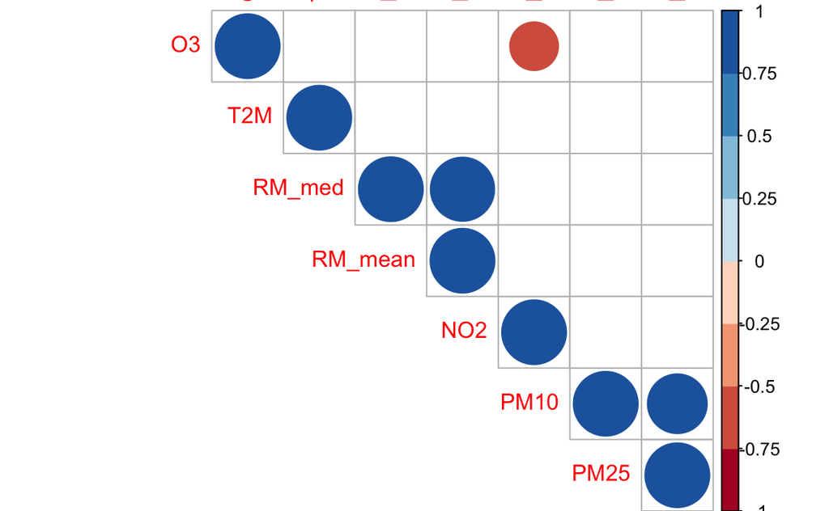

### Prepare the data

Before proceeding the data frame will be stored as a *sparse matrix*. The MORTALITY_RATE column will be treated as a target variable and therefore removed from the matrix:

Data will be stored using `DGMatrix` class, which is a recommended way

# Training and Tuning

Training is done using 5-fold CV, which is a common place to begin with cross validation. If your TEST set is a % of your TRAINING, you may want to consider replicating that split with your TRAINING only. That way you have the actual results when you predict on TEST and can see where your algorithms are underperforming or overfitting.

```r
################# Loop 5x initially to see where the values converge, then 50
# Automated to run and may take a long time.
#####################
nloops<-20 # Set this for the number of random loops
best_param = list() # You will store your best set of parameters here
best_seednumber = 1969 # Initialize to same number for starters
best_error = Inf # Set to infinity for starters
best_error_index = 0
best_history<-NULL
cv.nround = 500 # Set to number of rounds you'd like it to fit - usually higher
cv.nfold = 5 # 5-Fold Validation
cv.earlystop = 5 # Stop after consecutive rounds of no improvement

for (iter in 1:nloops) {
  param <- list(objective = "reg:linear", # Objective for the algorithm
                #booster="gblinear", # Make sure this aligns to your objective
                eval_metric="rmse",
                max_depth = sample(1:20, 1), # Range 8-11 common 8
                eta = runif(1, .5, .9), # Range .1-.3, common 0.8
                gamma = runif(1, 0.0, 0.2), # Range 0-.2
                subsample = runif(1, .6, .9), # Range 0.6-0.9 common 0.7
                colsample_bytree = runif(1, .5, .8), # Range .5-.8 common 0.7
                min_child_weight = sample(1:40, 1), # Range 1-40
                max_delta_step = sample(1:10, 1) # Range 1-10
  )
  seed.number = sample.int(10000, 1)[[1]]
  set.seed(seed.number)
  history <- xgb.cv(data=dtrain,
                 params = param,
                 #watchlist = watchlist,
                 nfold=cv.nfold,
                 nrounds=cv.nround,
                 verbose = F, # Change to T if you'd like to see it learn
                 early.stop.round=cv.earlystop,
                 #feval=rmpse, # custom evaluation metric function call
                 maximize=FALSE)
  huh<-as.data.frame(history$test.rmse.mean)
  m_error = min(huh) # Make sure you change this if using a different function or err name
  m_error_index = which(huh==min(huh)) # Sets the number of rounds

  if (m_error < best_error) {
    best_error = m_error
    best_error_index = m_error_index
    best_seednumber = seed.number
    best_param = param
    best_history = history
  }
  cat("  Loop:", iter,"  Error:",m_error,"\n"); # Shows which random iteration you are on
}
############################################
# END XGBoost Tuning
############################################
```

## Train XGBoost

```r
######################################
# Train XGB Model
######################################
train.full.sparse <- sparse.model.matrix(target~., data=train.full)
dtrain <- xgb.DMatrix(
  data=train.full.sparse,
  label=keep.target,
  missing = NaN)
dtest <-data.matrix(test.full, rownames.force = NA)

clf <- xgb.train(   params              = best_param,
                    data                = dtrain,
                    nrounds             = best_error_index,
                    verbose             = F,
                    maximize            = FALSE
)
```

## Make predictions and generate a Submission File

```r
##########################
# Begin Predictions on Test Data
##########################

# Make XGB Predictions
pred.xgb <- rep(0,nrow(test.full))
pred.xgb <- round(predict(clf, dtest),10)
# store in frame, may be able to add other models to ensemble later
airqualitypred <- data.frame(Id=keep.id, mortality_rate=pred.xgb)
###################################################################
# Write out submission files
write.csv(data.frame("Id"=airqualitypred$Id, "mortality_rate"=airqualitypred$mortality_rate), "~/Desktop/Data/Kaggle/AirQuality/baseXGB.csv", row.names = F)
```